# Coronavirus US Data (as of 20-AUG-2020)

davegoblue

8/21/2020

## Background

This file is for analysis of some data downloaded from [The COVID Tracking Project](https://covidtracking.com/) on 20 August, 2020. This file contains data on positive tests, hospitalizations, deaths, and the like for coronavirus cases in the US. Data are unique by state and date.

#### *Data Availability*

The downloaded data file is read in as CSV, and the date column is converted to date format:

```r
library(tidyverse)
cvData <- readr::read_csv("./RInputFiles/Coronavirus/CV_downloaded_200820.csv")
glimpse(cvData)
```

```
## Observations: 9,449
## Variables: 53
## $ date                        <dbl> 20200820, 20200820, 20200820, 20200820,...
## $ state                       <chr> "AK", "AL", "AR", "AS", "AZ", "CA", "CO...
## $ positive                    <dbl> 5332, 112449, 54765, 0, 196280, 644751,...
## $ negative                    <dbl> 307315, 784330, 593744, 1514, 922163, 9...
## $ pending                     <dbl> NA, NA, NA, NA, NA, NA, NA, NA, NA, NA,...
## $ hospitalizedCurrently       <dbl> 51, 1105, 499, NA, 1070, 6212, 238, 47,...
## $ hospitalizedCumulative      <dbl> NA, 13330, 3790, NA, 21143, NA, 6784, 1...
## $ inIcuCurrently              <dbl> NA, NA, NA, NA, 388, 1707, NA, NA, 26, ...
## $ inIcuCumulative             <dbl> NA, 1348, NA, NA, NA, NA, NA, NA, NA, N...
## $ onVentilatorCurrently       <dbl> 6, NA, 108, NA, 233, NA, NA, NA, 12, NA...
## $ onVentilatorCumulative      <dbl> NA, 734, 488, NA, NA, NA, NA, NA, NA, N...
## $ recovered                   <dbl> 1513, 44684, 48458, NA, 28471, NA, 5759...
## $ dataQualityGrade            <chr> "A", "B", "A", "C", "A+", "B", "A", "B"...
```

[output cut: 40 more lines]

```r
cvData <- cvData %>%
    mutate(date=lubridate::ymd(date))
glimpse(cvData)
```

```
## Observations: 9,449
## Variables: 53
## $ date                        <date> 2020-08-20, 2020-08-20, 2020-08-20, 20...
## $ state                       <chr> "AK", "AL", "AR", "AS", "AZ", "CA", "CO...
## $ positive                    <dbl> 5332, 112449, 54765, 0, 196280, 644751,...
## $ negative                    <dbl> 307315, 784330, 593744, 1514, 922163, 9...
## $ pending                     <dbl> NA, NA, NA, NA, NA, NA, NA, NA, NA, NA,...
## $ hospitalizedCurrently       <dbl> 51, 1105, 499, NA, 1070, 6212, 238, 47,...
## $ hospitalizedCumulative      <dbl> NA, 13330, 3790, NA, 21143, NA, 6784, 1...
## $ inIcuCurrently              <dbl> NA, NA, NA, NA, 388, 1707, NA, NA, 26, ...
## $ inIcuCumulative             <dbl> NA, 1348, NA, NA, NA, NA, NA, NA, NA, N...
## $ onVentilatorCurrently       <dbl> 6, NA, 108, NA, 233, NA, NA, NA, 12, NA...
## $ onVentilatorCumulative      <dbl> NA, 734, 488, NA, NA, NA, NA, NA, NA, N...
## $ recovered                   <dbl> 1513, 44684, 48458, NA, 28471, NA, 5759...
## $ dataQualityGrade            <chr> "A", "B", "A", "C", "A+", "B", "A", "B"...
```

[output cut: 40 more lines]

```r
cvData %>%
    select(date, state) %>%
    anyDuplicated()
```

```
## [1] 0
```

As expected, the file is unique by date and state. The date field has been converted from double to date. The main columns of interest will be:

- date
- state
- positiveIncrease - number of new positive cases for state during date
- deathIncrease - number of new deaths for state during date

A smaller frame containing only this data is created:

```r
cvUse <- cvData %>%
    select(date, state, cases=positiveIncrease, deaths=deathIncrease)

cvUse %>%
    summarize_if(is.numeric, sum)
```

```
## # A tibble: 1 x 2
##     cases deaths
##     <dbl>  <dbl>
## 1 5546056 166127
```

The numeric totals match those reported by the COVID Tracking Project for the same date. They are roughly 5% lower than the totals reported by worldometers.info. There are significant issues associated with official reporting for corornavirus, and a 5% discrepancy between sources is not unexpected.

The data are next checked for totals by state and by week:

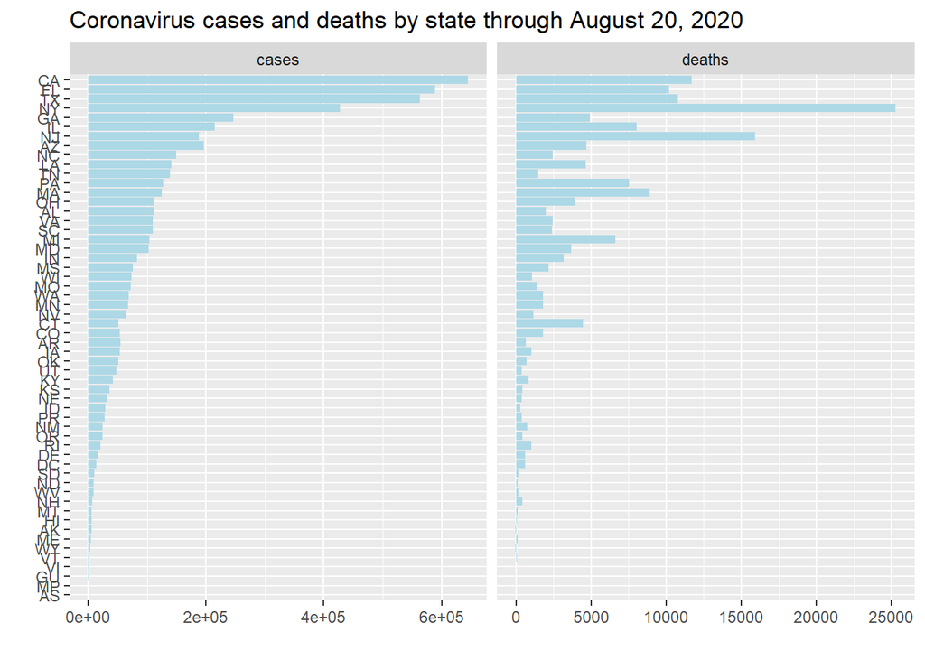

```r
cvUse %>%
    group_by(state) %>%
    summarize_if(is.numeric, sum) %>%
    pivot_longer(-state) %>%
    ggplot(aes(x=fct_reorder(state, value), y=value)) +
    geom_col(fill="lightblue") +
    coord_flip() +
    facet_wrap(~name, scales="free_x") +
    labs(x="", y="", title="Coronavirus cases and deaths by state through August 20, 2020")
```

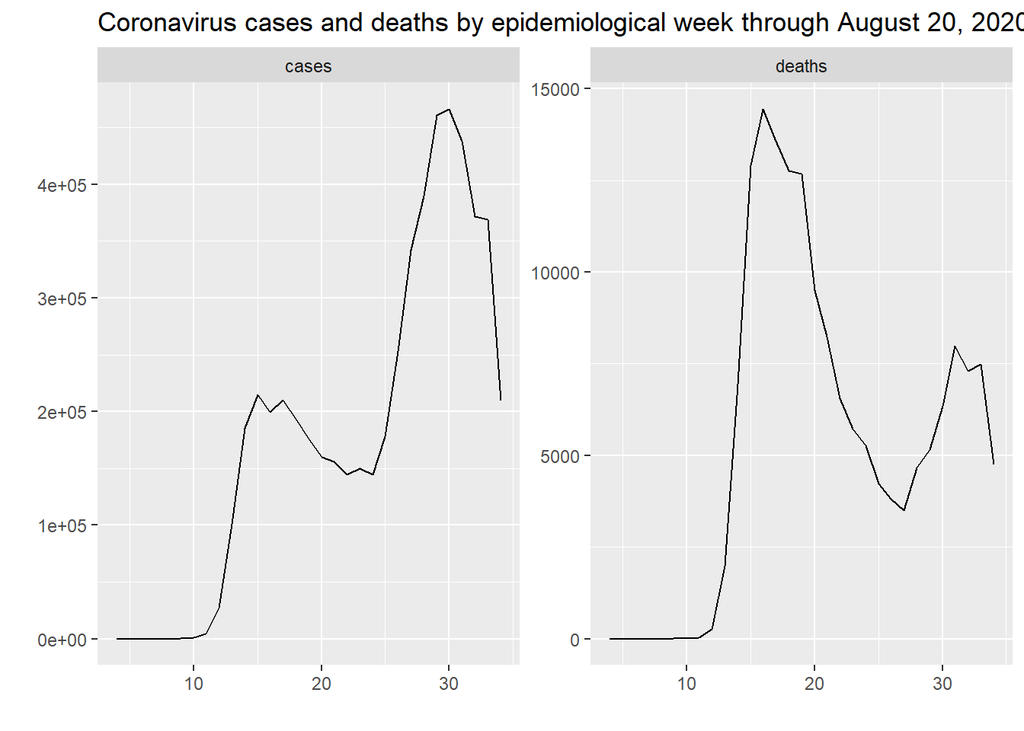

```r
cvUse %>%
    group_by(week=lubridate::epiweek(date)) %>%
    summarize_if(is.numeric, sum) %>%
    pivot_longer(-week) %>%
    ggplot(aes(x=week, y=value)) +
    geom_line() +
    facet_wrap(~name, scales="free_y") +
    labs(x="", y="", title="Coronavirus cases and deaths by epidemiological week through August 20, 2020")
```

Sort order by state generally matches published reports of coronavirus burden by state. The weekly data appear broadly aligned with other published data. The dip in the final week is due to only 5 of the 7 days of the week being included in the Thursday data file.

State population data (2015 estimates) are obtained from usmap for converting metrics to per capita, and the cvData file is filtered to only those observations contained in the state population file:

```r
statePop <- usmap::statepop %>%
    select(state=abbr, name=full, pop_2015)
glimpse(statePop)
```

```
## Observations: 51
## Variables: 3
## $ state    <chr> "AL", "AK", "AZ", "AR", "CA", "CO", "CT", "DE", "DC", "FL"...
## $ name     <chr> "Alabama", "Alaska", "Arizona", "Arkansas", "California", ...
## $ pop_2015 <dbl> 4858979, 738432, 6828065, 2978204, 39144818, 5456574, 3590...
```

```r
cvUse <- cvUse %>%
    semi_join(statePop)
cvUse %>%
    summarize_if(is.numeric, sum)
```

```
## # A tibble: 1 x 2
##     cases deaths
##     <dbl>  <dbl>
## 1 5516295 165742
```

Over 99% of the cases and deaths are preserved when the territories and other non-state data are removed.

There appear to be at least two peaks in the case and death data, likely driven by different locales experiencing outbreaks at different times. Per capita cases and deaths by state are plotted:

```r
# Per capita metrics by state
cvStatePerCapita <- cvUse %>%
    group_by(state) %>%
    summarize_if(is.numeric, sum) %>%
    inner_join(statePop) %>%
    mutate(cases=1000000*cases/pop_2015, deaths=1000000*deaths/pop_2015)
```

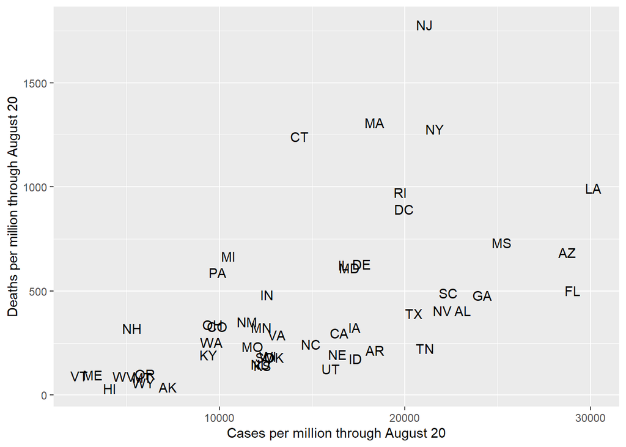

```r
# Disease burden by state, per capita
cvStatePerCapita %>%
    ggplot(aes(x=cases, y=deaths)) +
    geom_text(aes(label=state)) +
    labs(x="Cases per million through August 20", y="Deaths per million through August 20")
```

States will be defined as having a low impact of disease if 1) deaths per million are 100 or less, and 2) cases per million are 10000 or less:

```r
lowBurden <- cvStatePerCapita %>%
    filter(deaths <= 100, cases <= 10000) %>%
    pull(state)
```

```r
# Calculate the raw data
clustData <- cvUse %>%
    filter(!(state %in% lowBurden)) %>%
    inner_join(statePop) %>%
    mutate(month=lubridate::month(date), cpm=1000000*cases/pop_2015, dpm=1000000*deaths/pop_2015) %>%
    filter(date >= as.Date("2020-03-15")) %>%
    group_by(state, month) %>%
    summarize(dpm=sum(dpm), cpm=sum(cpm), n=n()) %>%
    pivot_wider(state, names_from=month, values_from=c(dpm, cpm)) %>%
    ungroup()
```

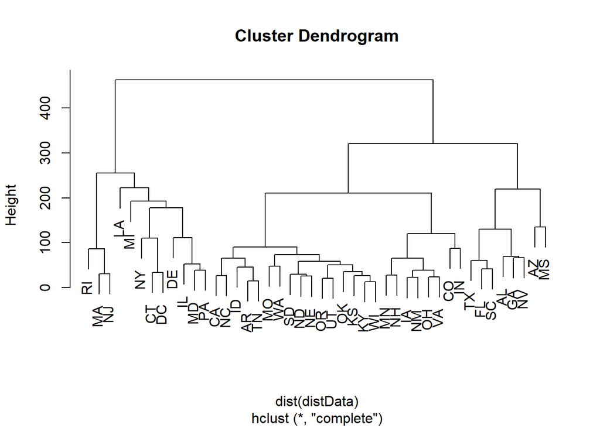

```r
# Run clusters without normalization, but with dpm limited to 300
distData <- clustData %>%
    select(state, starts_with("dpm")) %>%
    mutate_if(is.numeric, .funs=~pmin(., 300)) %>%
    column_to_rownames("state")

cvTree <- hclust(dist(distData))

# Plot the dendrogram
plot(cvTree)
```

There appears to be a cluster of states that had early outbreaks, a cluster of states that had later outbreaks, and a large segment that falls in between these extremes. Suppose the dendrogram is split in to three clusters, with the low burden states added as a fourth cluster:

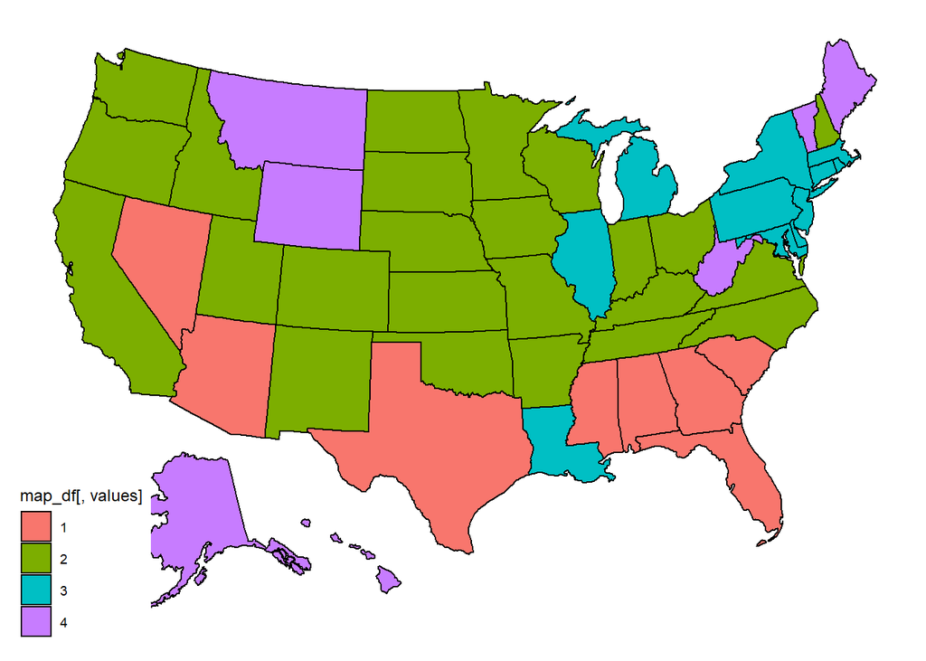

```r
# Get the clusters from the tree, adding the low burden states as cluster 4
cvClusters <- c(cutree(cvTree, k=3),
                rep(4, length(lowBurden)) %>% set_names(lowBurden)
                )

# Add the clusters to the population data file
statePop <- statePop %>%
    mutate(cluster=factor(cvClusters[state]))

# Show a map of the clusters
usmap::plot_usmap(regions="states", data=statePop, values="cluster")
```

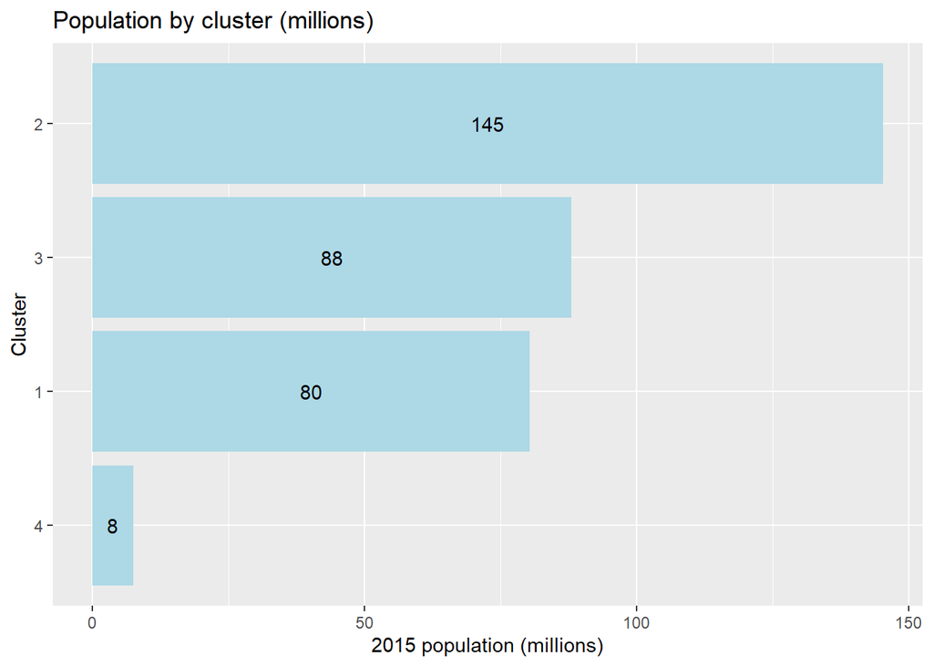

```r
# Show population totals by cluster
statePop %>%
    group_by(cluster) %>%
    summarize(pop_2015=sum(pop_2015)/1000000) %>%
    ggplot(aes(x=fct_reorder(cluster, pop_2015), y=pop_2015)) +
    geom_col(fill="lightblue") +
    geom_text(aes(y=pop_2015/2, label=round(pop_2015))) +
    labs(y="2015 population (millions)", x="Cluster", title="Population by cluster (millions)") +
    coord_flip()
```

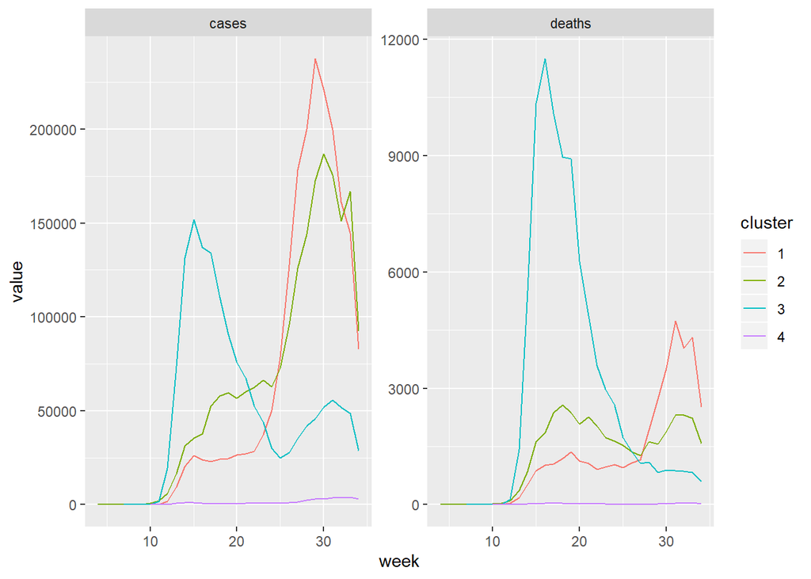

```r
# Virus by week by cluster
cvUse %>%
    mutate(cluster=factor(cvClusters[state]), week=lubridate::epiweek(date)) %>%
    group_by(cluster, week) %>%
    summarize(cases=sum(cases), deaths=sum(deaths)) %>%
    pivot_longer(-c(week, cluster)) %>%
    ggplot(aes(x=week, y=value, group=cluster, color=cluster)) +
    geom_line() +
    facet_wrap(~name, scales="free_y")
```

Metrics can be normalized by population to look at coronavirus burden per capita by segment over time:

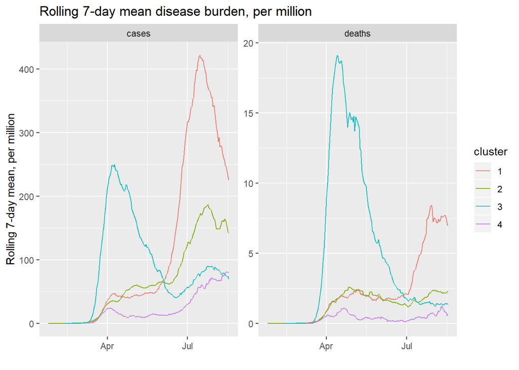

```r
# Integrated data file
cvWeekPop <- cvUse %>%
    mutate(week=lubridate::epiweek(date)) %>%
    inner_join(statePop, by="state")

# Summarized by date-cluster
cvDateCluster <- cvWeekPop %>%
    group_by(date, cluster) %>%
    summarize(cases=sum(cases), deaths=sum(deaths)) %>%
    inner_join(statePop %>% group_by(cluster) %>% summarize(pop_mill=sum(pop_2015)/1000000), by="cluster") %>%
    group_by(cluster) %>%
    mutate(cpm7=zoo::rollmean(cases, 7, fill=NA)/pop_mill,
           dpm7=zoo::rollmean(deaths, 7, fill=NA)/pop_mill
           ) %>%
    ungroup()

# Plotted by date
cvDateCluster %>%
    select(date, cluster, cases=cpm7, deaths=dpm7) %>%
    pivot_longer(-c(date, cluster)) %>%
    filter(!is.na(value)) %>%
    ggplot(aes(x=date, y=value, group=cluster, color=cluster)) +
    geom_line() +
    facet_wrap(~name, scales="free_y") +
    labs(x="", y="Rolling 7-day mean, per million", title="Rolling 7-day mean disease burden, per million")
```

Broadly speaking:

- Segment 4, which is small states with low coronavirus burden, may be experiencing a small rise in both cases and deaths
- Segment 3, which is much of the northeast plus MI, IL, and LA has a significant spike early followed by a rapid and largely sustained decline
- Segment 1, which is largely the south ex-LA/NM, appears to have peaked in cases by the middle of July and to be starting to decline in deaths as of the middle of August
- Segment 2, which is about half the country, appears similar to Segment 1 but with a much less pronounced spike in both cases and deaths in July/August

There appear to be meaningful differences in disease burden over time, and with a meaningful geographical explanatory component.

Next, the total volume of disease through August 20 is explored by state:

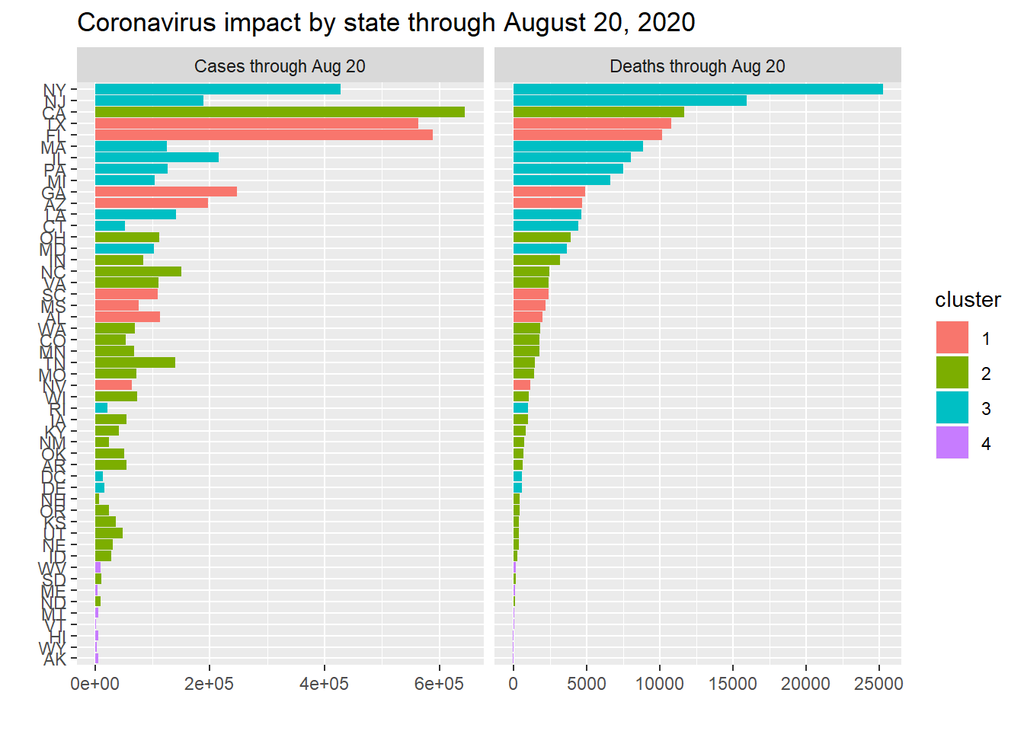

```r
varMapper <- c("cases"="Cases through Aug 20",
               "newCases"="Increase in cases, 30 days through Aug 20",
               "casesroll7"="Rolling 7-day mean cases, through Aug 20",
               "deaths"="Deaths through Aug 20",
               "newDeaths"="Increase in deaths, 30 days through Aug 20",
               "deathsroll7"="Rolling 7-day mean deaths, through Aug 20",
               "cpm"="Cases through Aug 20 (per million)",
               "cpm7"="Cases per day (7-day rolling mean) through Aug 20 (per million)",
               "newcpm"="Increase in cases, 30 days through Aug 20 (per million)",
               "dpm"="Deaths through Aug 20 (per million)",
               "dpm7"="Deaths per day (7-day rolling mean) through Aug 20 (per million)",
               "newdpm"="Increase in deaths, 30 days through Aug 20 (per million)"
               )

cvWeekPop %>%
    group_by(state, cluster) %>%
    summarize(cases=sum(cases), deaths=sum(deaths), pop_2015=mean(pop_2015)) %>%
    ungroup() %>%
    mutate(cpm=1000000*cases/pop_2015, dpm=1000000*deaths/pop_2015) %>%
    select(state, cluster, cases, deaths) %>%
    pivot_longer(c(cases, deaths)) %>%
    ggplot(aes(x=fct_reorder(state, value, .fun=min), y=value)) +
    geom_col(aes(fill=cluster)) +
    coord_flip() +
    labs(x="", y="", title="Coronavirus impact by state through August 20, 2020") +
    facet_wrap(~varMapper[name], scales="free_x")
```

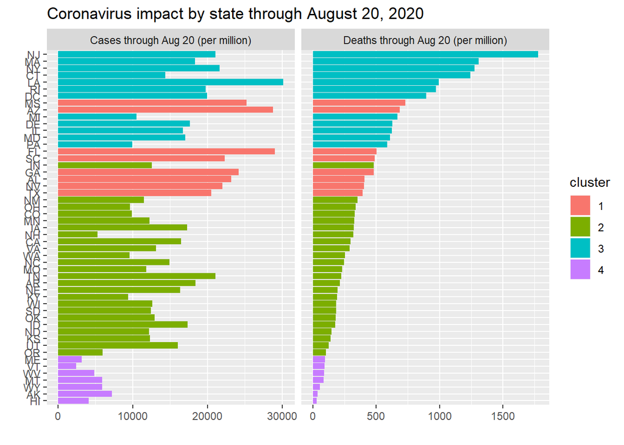

```r
cvWeekPop %>%
    group_by(state, cluster) %>%
    summarize(cases=sum(cases), deaths=sum(deaths), pop_2015=mean(pop_2015)) %>%
    ungroup() %>%
    mutate(cpm=1000000*cases/pop_2015, dpm=1000000*deaths/pop_2015) %>%
    select(state, cluster, cpm, dpm) %>%
    pivot_longer(c(cpm, dpm)) %>%
    ggplot(aes(x=fct_reorder(state, value, .fun=min), y=value)) +
    geom_col(aes(fill=cluster)) +
    coord_flip() +
    labs(x="", y="", title="Coronavirus impact by state through August 20, 2020") +
    facet_wrap(~varMapper[name], scales="free_x")
```

As expected, the segmentation approach has largely divided the states by total coronavirus burden. Mississippi and Arizona are in segment 1 due to the late nature of their outbreak.

Further, the data are explored for a combination of total disease burden and change over the past 30 days:

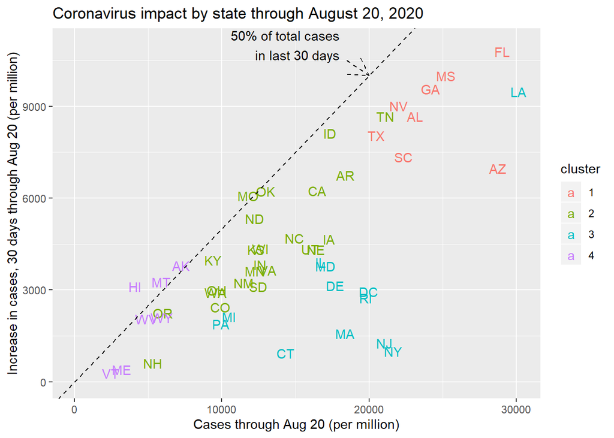

```r
cvWeekPop %>%
    mutate(newCases=ifelse(as.Date("2020-08-21")-date <= 30, cases, 0),
           newDeaths=ifelse(as.Date("2020-08-21")-date <= 30, deaths, 0)
           ) %>%
    group_by(state, cluster) %>%
    summarize(cases=sum(cases),
              deaths=sum(deaths),
              newCases=sum(newCases),
              newDeaths=sum(newDeaths),
              pop_2015=mean(pop_2015)
              ) %>%
    ungroup() %>%
    mutate(cpm=1000000*cases/pop_2015,
           dpm=1000000*deaths/pop_2015,
           newcpm=1000000*newCases/pop_2015,
           newdpm=1000000*newDeaths/pop_2015
           ) %>%
    ggplot(aes(x=cpm, y=newcpm)) +
    geom_text(aes(color=cluster, label=state)) +
    labs(x=varMapper["cpm"],
         y=varMapper["newcpm"],
         title="Coronavirus impact by state through August 20, 2020"
         ) +
    geom_abline(lty=2, slope=c(0.5)) +
    lims(x=c(0, NA), y=c(0, NA)) +
    annotate("text", x=18000, y=11000, label="50% of total cases\nin last 30 days", hjust=1) +
    annotate("segment", x=18500, y=10500, xend=20000, yend=10000, arrow=arrow(), lty=2)
```

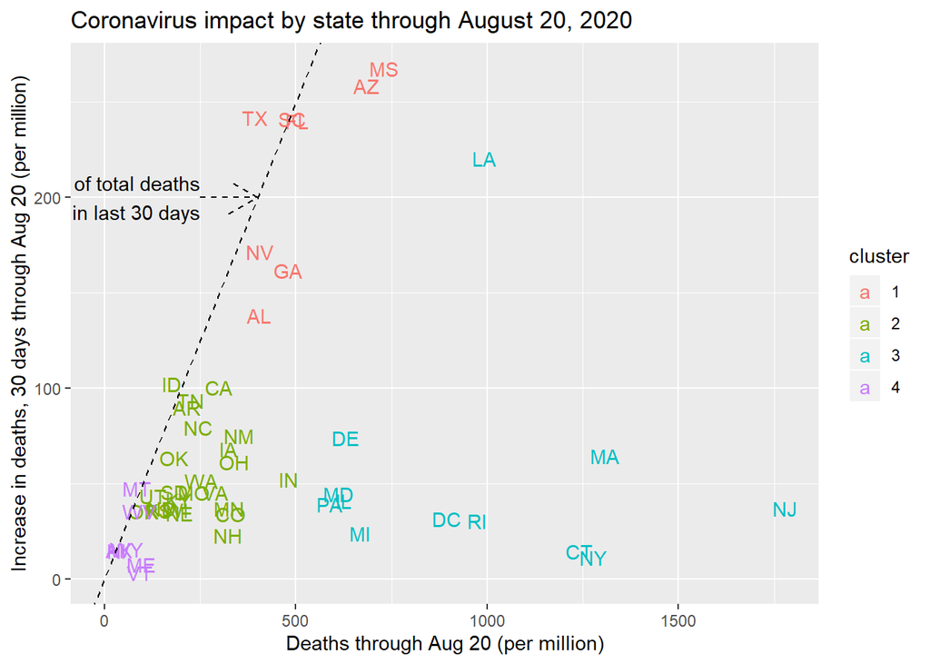

```r
cvWeekPop %>%
    mutate(newCases=ifelse(as.Date("2020-08-21")-date <= 30, cases, 0),
           newDeaths=ifelse(as.Date("2020-08-21")-date <= 30, deaths, 0)
           ) %>%
    group_by(state, cluster) %>%
    summarize(cases=sum(cases),
              deaths=sum(deaths),
              newCases=sum(newCases),
              newDeaths=sum(newDeaths),
              pop_2015=mean(pop_2015)
              ) %>%
    ungroup() %>%
    mutate(cpm=1000000*cases/pop_2015,
           dpm=1000000*deaths/pop_2015,
           newcpm=1000000*newCases/pop_2015,
           newdpm=1000000*newDeaths/pop_2015
           ) %>%
    ggplot(aes(x=dpm, y=newdpm)) +
    geom_text(aes(color=cluster, label=state)) +
    labs(x=varMapper["dpm"],
         y=varMapper["newdpm"],
         title="Coronavirus impact by state through August 20, 2020"
         ) +
    geom_abline(lty=2, slope=c(0.5)) +
    lims(x=c(0, NA), y=c(0, NA)) +
    annotate("text", x=250, y=200, label="50% of total deaths\nin last 30 days", hjust=1) +
    annotate("segment", x=250, y=200, xend=400, yend=200, arrow=arrow(), lty=2)
```

The clusters appear relatively well separated, with the possible exception of Louisiana which is arguably quite close to cluster 1. Cluster 3 stands out as having had a very high overall impact, but with not much of an increase in the past 30 days.

The individual trends by state are also plotted, smoothed by week:

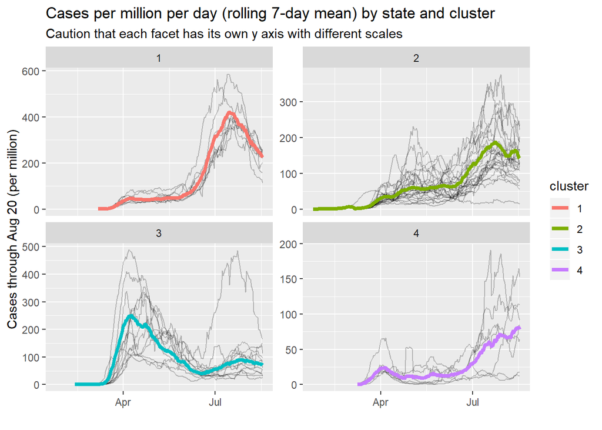

```r
cvWeekPop %>%
    rbind(mutate(., state="cluster")) %>%
    group_by(state, cluster, date) %>%
    summarize_if(is.numeric, sum) %>%
    ungroup() %>%
    mutate(cpm=1000000*cases/pop_2015, dpm=1000000*deaths/pop_2015) %>%
    group_by(state, cluster) %>%
    mutate(cpm7=zoo::rollmean(cpm, k=7, fill=NA), dpm7=zoo::rollmean(dpm, k=7, fill=NA)) %>%
    ungroup() %>%
    filter(!is.na(cpm7)) %>%
    ggplot(aes(x=date, y=cpm7)) +
    geom_line(data=~filter(., state != "cluster"), aes(group=state), alpha=0.25) +
    geom_line(data=~filter(., state == "cluster"), aes(group=state, color=cluster), lwd=1.5) +
    facet_wrap(~cluster, scales="free_y") +
    labs(x="",
         y=varMapper["cpm"],
         title="Cases per million per day (rolling 7-day mean) by state and cluster",
         subtitle="Caution that each facet has its own y axis with different scales"
         ) +
    ylim(c(0, NA))
```

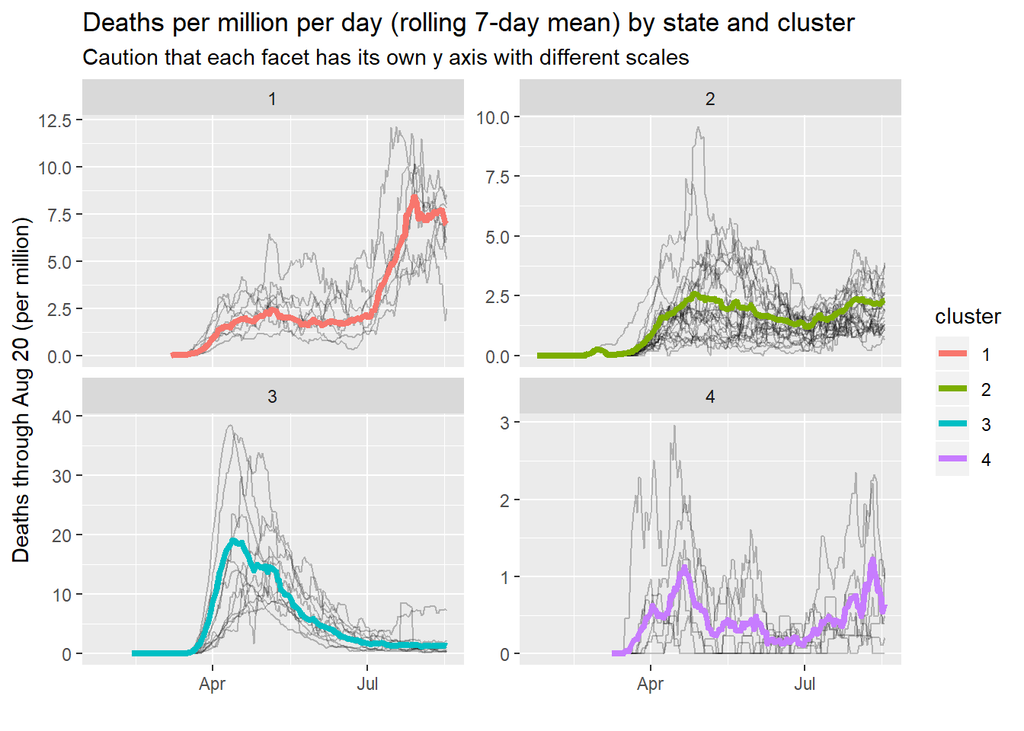

```r
cvWeekPop %>%
    rbind(mutate(., state="cluster")) %>%
    group_by(state, cluster, date) %>%
    summarize_if(is.numeric, sum) %>%
    ungroup() %>%
    mutate(cpm=1000000*cases/pop_2015, dpm=1000000*deaths/pop_2015) %>%
    group_by(state, cluster) %>%
    mutate(cpm7=zoo::rollmean(cpm, k=7, fill=NA), dpm7=zoo::rollmean(dpm, k=7, fill=NA)) %>%
    ungroup() %>%
    filter(!is.na(dpm7)) %>%
    ggplot(aes(x=date, y=dpm7)) +
    geom_line(data=~filter(., state != "cluster"), aes(group=state), alpha=0.25) +
    geom_line(data=~filter(., state == "cluster"), aes(group=state, color=cluster), lwd=1.5) +
    facet_wrap(~cluster, scales="free_y") +
    labs(x="",
         y=varMapper["dpm"],
         title="Deaths per million per day (rolling 7-day mean) by state and cluster",
         subtitle="Caution that each facet has its own y axis with different scales"
         ) +
    ylim(c(0, NA))
```

With a few exceptions in a rather noisy segment 2 (as well as Louisiana in segment 3), states seem to broadly follow the disease state pattern for their cluster, though with some differences in magnitude and timing.

The process is converted to functional form so that it can be run using different data. First, a function is written to read in the data:

```r
# Function to read in the raw coronavirus data file (assume it is already downloaded)
readCVData <- function(fileName,
                       showGlimpse=TRUE,
                       uqVars=c("date", "state"),
                       errDups=TRUE
                       ) {

    # FUNCTION ARGUMENTS
    # fileName: location of the downloded CSV file from COVID Tracking Project
    # showGlimpse: boolean, whether to run glimpse() on the file
    # uqVars: variables that the file is expected to be unique by
    # errDups: boolean, whether to error out if uniqueness is violated

    # Read in the file and convert the 'date' from double to date
    cvData <- readr::read_csv(fileName) %>%
        mutate(date=lubridate::ymd(date))

    # See a sample of the data
    if (showGlimpse) glimpse(cvData)

    # Check that the data are unique by date and state
    nDups <- cvData %>%
        select_at(vars(all_of(uqVars))) %>%
        anyDuplicated()

    # Inform of the uniqueness check results
    if (nDups==0) {
        cat("\nFile is unique by:", uqVars, "and has dimensions:", dim(cvData), "\n")
    } else {
        cat("\nUniqueness check failed, file has duplicates by:", uqVars, "\n")
        if (errDups) stop("Fix and re-run")
    }

    # Return the file
    cvData

}

cvFull <- readCVData("./RInputFiles/Coronavirus/CV_downloaded_200820.csv")
```

```
## Observations: 9,449
## Variables: 53
## $ date                        <date> 2020-08-20, 2020-08-20, 2020-08-20, 20...
## $ state                       <chr> "AK", "AL", "AR", "AS", "AZ", "CA", "CO...
## $ positive                    <dbl> 5332, 112449, 54765, 0, 196280, 644751,...
## $ negative                    <dbl> 307315, 784330, 593744, 1514, 922163, 9...
## $ pending                     <dbl> NA, NA, NA, NA, NA, NA, NA, NA, NA, NA,...
## $ hospitalizedCurrently       <dbl> 51, 1105, 499, NA, 1070, 6212, 238, 47,...
## $ hospitalizedCumulative      <dbl> NA, 13330, 3790, NA, 21143, NA, 6784, 1...
## $ inIcuCurrently              <dbl> NA, NA, NA, NA, 388, 1707, NA, NA, 26, ...
## $ inIcuCumulative             <dbl> NA, 1348, NA, NA, NA, NA, NA, NA, NA, N...
## $ onVentilatorCurrently       <dbl> 6, NA, 108, NA, 233, NA, NA, NA, 12, NA...
## $ onVentilatorCumulative      <dbl> NA, 734, 488, NA, NA, NA, NA, NA, NA, N...
## $ recovered                   <dbl> 1513, 44684, 48458, NA, 28471, NA, 5759...
## $ dataQualityGrade            <chr> "A", "B", "A", "C", "A+", "B", "A", "B"...
```

[output cut: 42 more lines]

Next, a function selects only the key variables of interest, filters to include only states (plus DC), and reports on relevant control totals:

```r
# Function to select relevant variables and observations, and report on control totals
processCVData <- function(dfFull,
                          varsKeep=c("date", "state", "positiveIncrease", "deathIncrease"),
                          varsRename=c("positiveIncrease"="cases", "deathIncrease"="deaths"),
                          stateList=c(state.abb, "DC")
                          ) {

    # FUNCTION ARGUMENTS
    # dfFull: the full data file originally loaded
    # varsKeep: variables to keep from the full file
    # varsRename: variables to be renamed, using a named vector of form originalName=newName
    # stateList: variables for filtering state (NULL means do not run any filters)

    # Select only the key variables
    df <- dfFull %>%
        select_at(vars(all_of(varsKeep)))

    # Apply the renaming of variables
    names(df) <- ifelse(is.na(varsRename[names(df)]), names(df), varsRename[names(df)])

    # Designate each record as being either a valid state or not
    if (!is.null(stateList)) {
        df <- df %>%
            mutate(validState=state %in% stateList)
    } else {
        df <- df %>%
            mutate(validState=TRUE)
    }

    # Summarize the control totals for the data, based on whether the state is valid
    cat("\n\nControl totals - note that validState other than TRUE will be discarded\n\n")
    df %>%
        mutate(n=1) %>%
        group_by(validState) %>%
        summarize_if(is.numeric, sum) %>%
        print()

    # Return the file, filtered to where validState is TRUE, and deleting variable validState
    df %>%
        filter(validState) %>%
        select(-validState)

}

cvFiltered <- processCVData(cvFull)
```

```
##
##
## Control totals - note that validState other than TRUE will be discarded
##
## # A tibble: 2 x 4
##   validState   cases deaths     n
##   <lgl>        <dbl>  <dbl> <dbl>
## 1 FALSE        29761    385   790
## 2 TRUE       5516295 165742  8659
```

Next, a state population data is processed for future use:

```r
# Function to extract and format key state data
getStateData <- function(df=usmap::statepop,
                         renameVars=c("abbr"="state", "full"="name", "pop_2015"="pop"),
                         keepVars=c("state", "name", "pop")
                         ) {

    # FUNCTION ARGUMENTS:
    # df: the data frame containing state data
    # renameVars: variables to be renamed, using named list with format "originalName"="newName"
    # keepVars: variables to be kept in the final file

    # Rename variables where appropriate
    names(df) <- ifelse(is.na(renameVars[names(df)]), names(df), renameVars[names(df)])

    # Return file with only key variables kept
    df %>%
        select_at(vars(all_of(keepVars)))

}

stateData <- getStateData()
```

Next, helper functions are written to convert a variable to per capita, or to convert a variable to a “rolling” mean:

```r
# Helper function to create per capita metrics
helperPerCapita <- function(df,
                            origVar,
                            newName,
                            byVar="state",
                            popVar="pop",
                            popData=stateData,
                            mult=1000000
                            ) {

    # FUNCTION ARGUMENTS:
    # df: the data frame currently being processed
    # origVar: the variables to be converted to per capita
    # newName: the new per capita variable name
    # byVar: the variable that will be merged by
    # popVar: the name of the population variable in the popData file
    # popData: the file containing the population data
    # mult: the multiplier, so that the metric is "per mult people"

    # Create the per capita variable
    df %>%
        inner_join(select_at(popData, vars(all_of(c(byVar, popVar)))), by=byVar) %>%
        mutate(!!newName:=mult*get(origVar)/get(popVar)) %>%
        select(-all_of(popVar))

}


# Helper function to create rolling aggregates
helperRollingAgg <- function(df,
                             origVar,
                             newName,
                             func=zoo::rollmean,
                             k=7,
                             fill=NA,
                             ...
                             ) {

    # FUNCTION ARGUMENTS:
    # df: the data frame containing the data
    # origVar: the original data column name
    # newName: the new variable column name
    # func: the function to be applied (zoo::rollmean will be by far the most common)
    # k: the periodicity (k=7 is rolling weekly data)
    # fill: how to fill leading.trailing data to maintain the same vector lengths
    # ...: any other arguments to be passed to func

    # Create the appropriate variable
    df %>%
        mutate(!!newName:=func(get(origVar), k=k, fill=fill, ...))

}



# Function to add per capita and rolling to the base data frame
helperMakePerCapita <- function(df,
                                k=7
                                ) {

    # FUNCTION ARGUMENTS:
    # df: the initial data frame for conversion
    # k: the rolling time period to use

    # Create the variables for cpm, dpm, cpm7, and dpm7
    dfNew <- df %>%
        helperPerCapita(origVar="cases", newName="cpm") %>%
        helperPerCapita(origVar="deaths", newName="dpm") %>%
        group_by(state) %>%
        arrange(date) %>%
        helperRollingAgg(origVar="cpm", newName=paste0("cpm", k), k=k) %>%
        helperRollingAgg(origVar="dpm", newName=paste0("dpm", k), k=k) %>%
        ungroup()

    # Return the new data frame
    dfNew

}


# Create the variables for cpm, dpm, cpm7, and dpm7
cvFilteredPerCapita <- helperMakePerCapita(cvFiltered, k=7)
cvFilteredPerCapita
```

```
## # A tibble: 8,659 x 8
##    date       state cases deaths   cpm   dpm    cpm7  dpm7
##    <date>     <chr> <dbl>  <dbl> <dbl> <dbl>   <dbl> <dbl>
##  1 2020-01-22 WA        0      0 0         0 NA         NA
##  2 2020-01-23 WA        0      0 0         0 NA         NA
##  3 2020-01-24 WA        0      0 0         0 NA         NA
##  4 2020-01-25 WA        0      0 0         0  0          0
##  5 2020-01-26 WA        0      0 0         0  0.0199     0
##  6 2020-01-27 WA        0      0 0         0  0.0199     0
##  7 2020-01-28 WA        0      0 0         0  0.0199     0
##  8 2020-01-29 WA        1      0 0.139     0  0.0398     0
##  9 2020-01-30 WA        0      0 0         0  0.0797     0
## 10 2020-01-31 WA        0      0 0         0  0.0996     0
## # ... with 8,649 more rows
```

Next, a function is written for creating side-by-side cases and death bar plots:

```r
# Function to create side-by-side plots for a deaths and cases metric
# Data in df will be aggregated to be unique by byVar using aggFunc
helperBarDeathsCases <- function(df,
                                 numVars,
                                 title="",
                                 xVar="state",
                                 fillVar=NULL,
                                 aggFunc=sum,
                                 mapper=varMapper
                                 ) {

    # FUNCTION ARGUMENTS:
    # df: the data frame containing the data
    # numVars: the relevant numeric variables for plotting
    # title: plot title, default is nothing
    # xVar: the x-axis variable for plotting
    # fillVar: the variable that will color the bars in the final plot (NULL means use "lightblue" for all)
    # aggFunc: the aggregate function (will be applied to create data unique by byVar)
    # mapper: mapping file to convert x/y variables to descriptive axes (named vector "variable"="label")

    # OVERALL FUNCTION PROCESS:
    # 1.  Variables in numVar are aggregated by aggFunc to be unique by c(xVar, fillVar)
    # 2.  Data are pivoted longer
    # 3.  Bar charts are created, with coloring by fillVar if provided

    # Create the byVar for summing
    byVar <- xVar
    if (!is.null(fillVar)) { byVar <- c(byVar, fillVar) }

    # Process the data and create the plot
    p1 <- df %>%
        select_at(vars(all_of(c(byVar, numVars)))) %>%
        group_by_at(vars(all_of(byVar))) %>%
        summarize_all(aggFunc) %>%
        pivot_longer(-all_of(byVar)) %>%
        ggplot(aes(x=fct_reorder(get(xVar), value, .fun=min), y=value)) +
        coord_flip() +
        facet_wrap(~mapper[name], scales="free_x") +
        labs(x="", y="", title=title) +
        if (is.null(fillVar)) geom_col(fill="lightblue") else geom_col(aes_string(fill=fillVar))

    # Print the plot
    print(p1)

}
```

A function is written to assess the raw state-level totals:

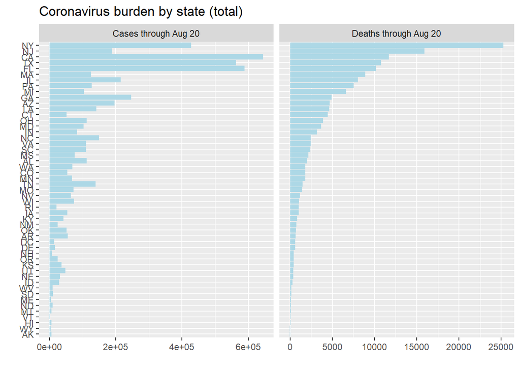

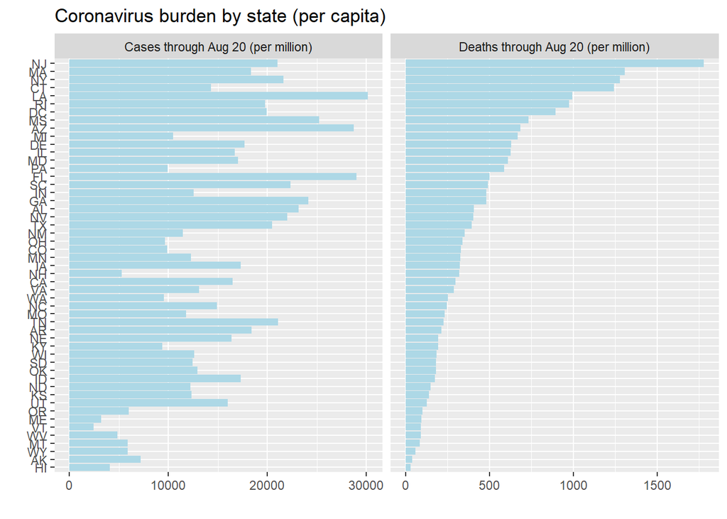

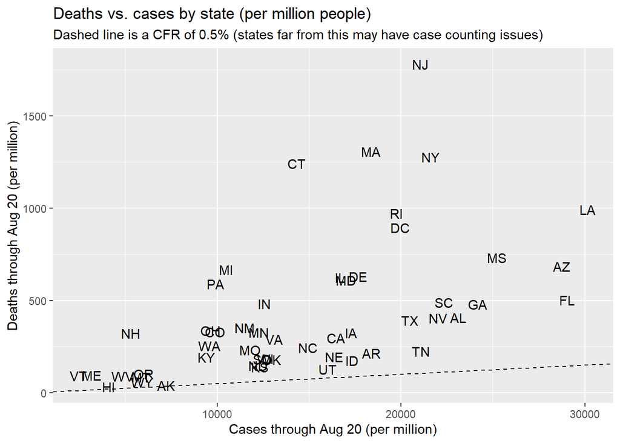

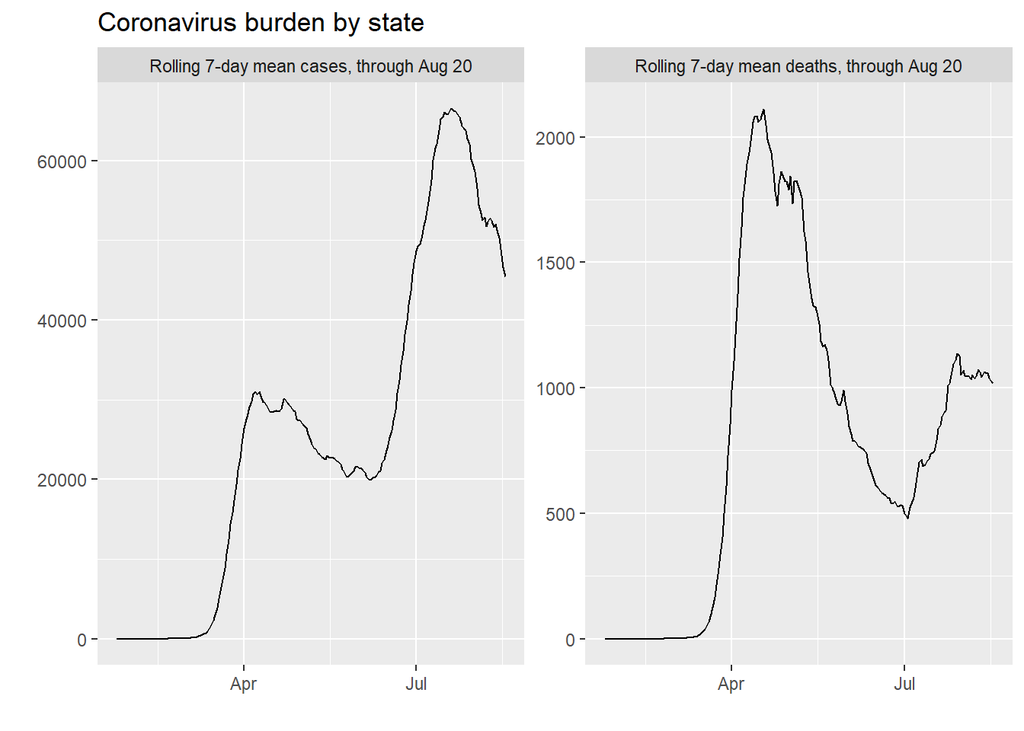

```r
# Function to assess state data (no segments created yet)
assessStateData <- function(df,
                            titleStem="Coronavirus burden by state",
                            cfrEst=0.005,
                            mapper=varMapper
                            ) {

    # FUNCTION ARGUMENTS:
    # df: the data frame containing the state-level data
    # titleStem: the main title description, with (total) or (per capita) appended
    # cfrEst: the estimated case fatality rate (CFR); a dashed abline will be plotted at this slope
    # mapper: mapping file to convert x/y variables to descriptive axes (named vector "variable"="label")

    # Plot cases and deaths by state, once for overall and once per capita
    helperBarDeathsCases(df, numVars=c("deaths", "cases"), title=paste0(titleStem, " (total)"))
    helperBarDeathsCases(df, numVars=c("dpm", "cpm"), title=paste0(titleStem, " (per capita)"))

    # Disease burden by state, per capita
    p1 <- df %>%
        group_by(state) %>%
        summarize(cpm=sum(cpm), dpm=sum(dpm)) %>%
        ggplot(aes(x=cpm, y=dpm)) +
        geom_text(aes(label=state)) +
        labs(x=mapper["cpm"],
             y=mapper["dpm"],
             title="Deaths vs. cases by state (per million people)",
             subtitle=paste0("Dashed line is a CFR of ",
                             round(100*cfrEst, 1),
                             "% (states far from this may have case counting issues)"
                             )
             ) +
        geom_abline(slope=cfrEst, lty=2)
    print(p1)

    # Total disease burden nationally by day, not using functional form
    p2 <- df %>%
        select(date, cases, deaths) %>%
        group_by(date) %>%
        summarize_if(is.numeric, sum) %>%
        ungroup() %>%
        helperRollingAgg(origVar="cases", newName="casesroll7") %>%
        helperRollingAgg(origVar="deaths", newName="deathsroll7") %>%
        select(-cases, -deaths) %>%
        pivot_longer(-date) %>%
        filter(!is.na(value)) %>%
        ggplot(aes(x=date, y=value)) +
        geom_line() +
        facet_wrap(~varMapper[name], scales="free_y") +
        labs(x="",
             y="",
             title=titleStem
             )
    print(p2)

}


# State-level assessments
assessStateData(cvFilteredPerCapita)
```

Next, functions for creating and assessing clusters are created. The approach can use either hierarchical clustering or k-means, and focus on the following variables:

- Aggregate cases
- Aggregate deaths
- Shape of case curve (percentage by week/month)
- Shape of death curve (percentage by week/month)

Cases is a tricky clustering variable since detection rates were in the single-digit percentages early in the outbreak (estimates of ~50x as many infected as diagnosed). As testing volumes increased, it is likely that a greater percentage of cases are diagnosed. States that have later outbreaks appear to have many more cases per capita but with a lower death rate per capita:

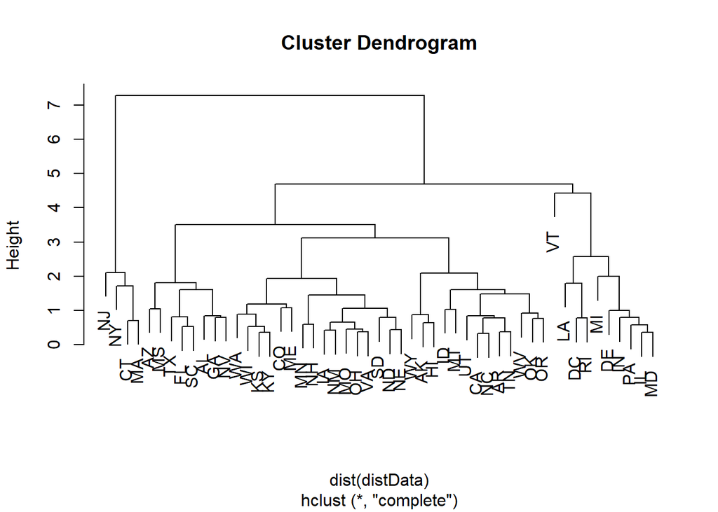

```r
# Function to create clusters for the state data (requires all data from same year, as currently true)
clusterStates <- function(df,
                          caseVar="cpm",
                          deathVar="dpm",
                          shapeFunc=lubridate::month,
                          minShape=NULL,
                          minDeath=0,
                          minCase=0,
                          ratioTotalvsShape=1,
                          ratioDeathvsCase=1,
                          hierarchical=TRUE,
                          method="complete"
                          ) {

    # FUNCTION ARGUMENTS:
    # df: the data frame containing cases and deaths data
    # caseVar: the variable containing the cases per capita data
    # deathVar: the variable containing the deaths per capita data
    # shapeFunc: the function to be used for creating the shape of the curve
    # minShape: the minimum value to be used for shape (to avoid very small amounts of data in Jan/Feb)
    #           NULL means keep everything
    # minDeath: use this value as a floor for the death metric when calculating shape
    # minCase: use this metric as a floor for the case metric when calculating shape
    # ratioTotalvsShape: amount of standard deviation to be kept in total variable vs shape variables
    # ratioDeathvsCase: amount of standard deviation to be kept in deaths vs cases
    #                   (total death data will be scaled to have sd this many times higher than cases)
    #                   (death percentages by time period will be scaled directly by this amount)
    # hierarchical: boolean, if TRUE run hierarchical clustering, otherwise run k-means clustering
    #               only hierarchical clustering is currently implemented
    # method: the method for hierarchical clustering (e.g., 'complete' or 'single')

    # Extract key information (aggregates and by shapeFunc for each state)
    df <- df %>%
        select_at(vars(all_of(c("date", "state", caseVar, deathVar)))) %>%
        purrr::set_names(c("date", "state", "cases", "deaths")) %>%
        mutate(timeBucket=shapeFunc(date)) %>%
        group_by(state, timeBucket) %>%
        summarize(cases=sum(cases), deaths=sum(deaths)) %>%
        ungroup()

    # Limit to only relevant time buckets if requested
    if (!is.null(minShape)) {
        df <- df %>%
            filter(timeBucket >= minShape)
    }

    # Extract an aggregate by state, scaled so that they have the proper ratio
    dfAgg <- df %>%
        group_by(state) %>%
        summarize(totalCases=sum(cases), totalDeaths=sum(deaths)) %>%
        ungroup() %>%
        mutate(totalDeaths=ratioDeathvsCase*totalDeaths*sd(totalCases)/sd(totalDeaths))

    # Extract the percentages (shapes) by month, scaled so that they have the proper ratio
    dfShape <- df %>%
        pivot_longer(-c(state, timeBucket)) %>%
        group_by(state, name) %>%
        mutate(tot=pmax(sum(value), ifelse(name=="deaths", minDeath, minCase)),
               value=ifelse(name=="deaths", ratioDeathvsCase, 1) * value / tot) %>%
        select(-tot) %>%
        pivot_wider(state, names_from=c(name, timeBucket), values_from=value) %>%
        ungroup()

    # Function to calculate SD of a subset of columns
    calcSumSD <- function(df) {
        df %>% ungroup() %>% select(-state) %>% summarize_all(.funs=sd) %>% as.vector() %>% sum()
    }
    # Down-weight the aggregate data so that there is the proper sum of sd in aggregates and shapes
    aggSD <- calcSumSD(dfAgg)
    shapeSD <- calcSumSD(dfShape)
    dfAgg <- dfAgg %>%
        mutate_if(is.numeric, ~. * ratioTotalvsShape * shapeSD / aggSD)

    # Combine so there is one row per state
    dfCluster <- dfAgg %>%
        inner_join(dfShape, by="state")

    # Create hierarchical segments or kmeans segments
    if (hierarchical) {
        distData <- dfCluster %>%
            column_to_rownames("state")
        objCluster <-  hclust(dist(distData), method=method)
        plot(objCluster)
    } else {
        cat("\nK-means is not yet implemented\n")
        objCluster <- NULL
    }

    # Return the clustering object
    objCluster

}

# Test clusters that weight deaths heavily vs. cases and that weight shape more highly than total
testCluster <- clusterStates(cvFilteredPerCapita,
                             minShape=3,
                             ratioDeathvsCase = 5,
                             ratioTotalvsShape = 0.5,
                             minDeath=100,
                             minCase=10000
                             )
```

The clusters can then be assessed against several criteria:

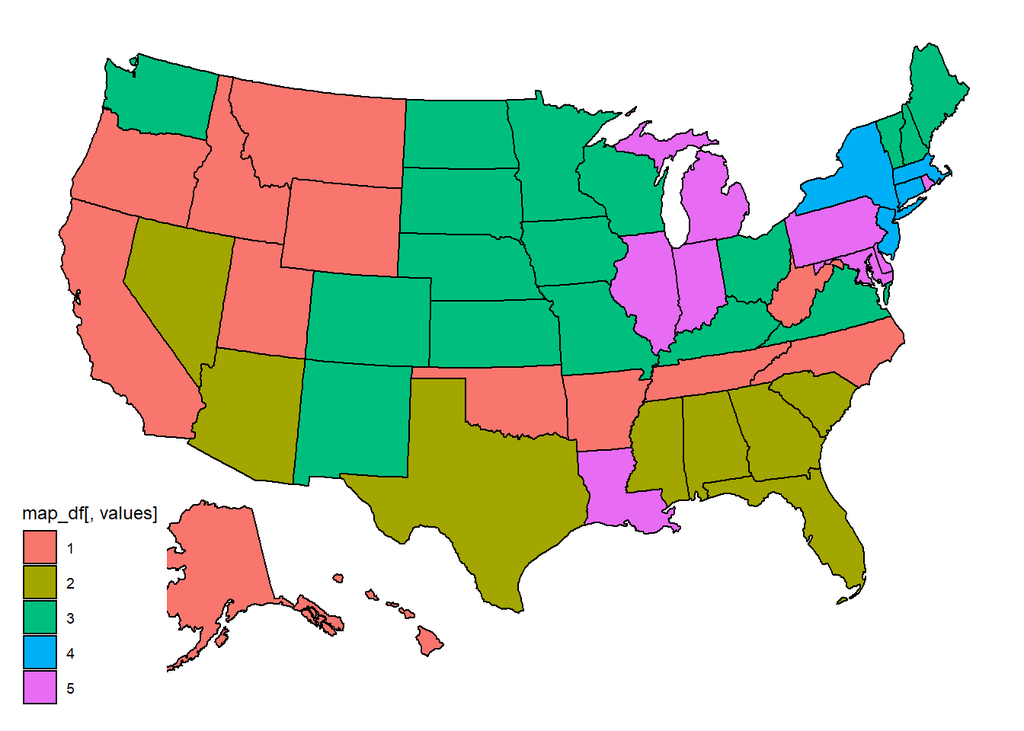

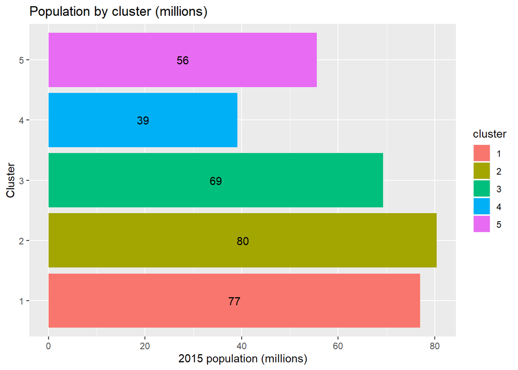

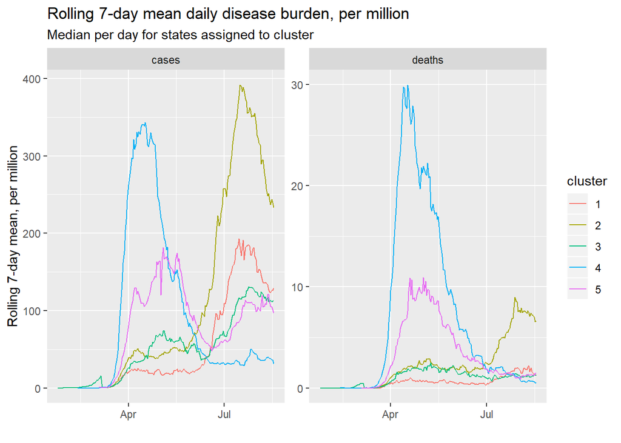

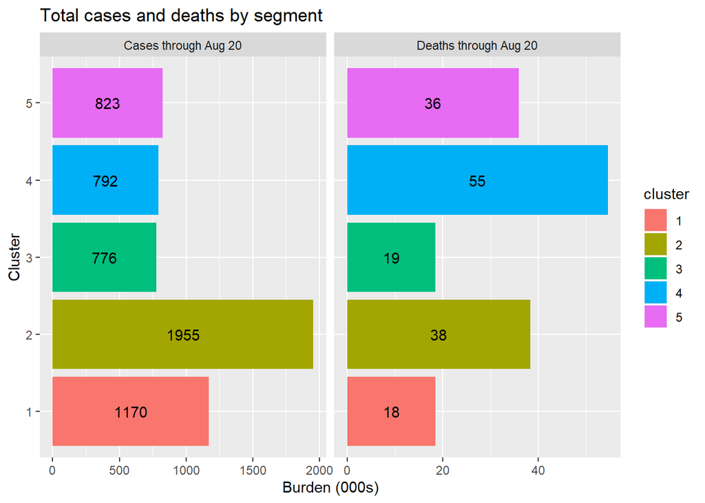

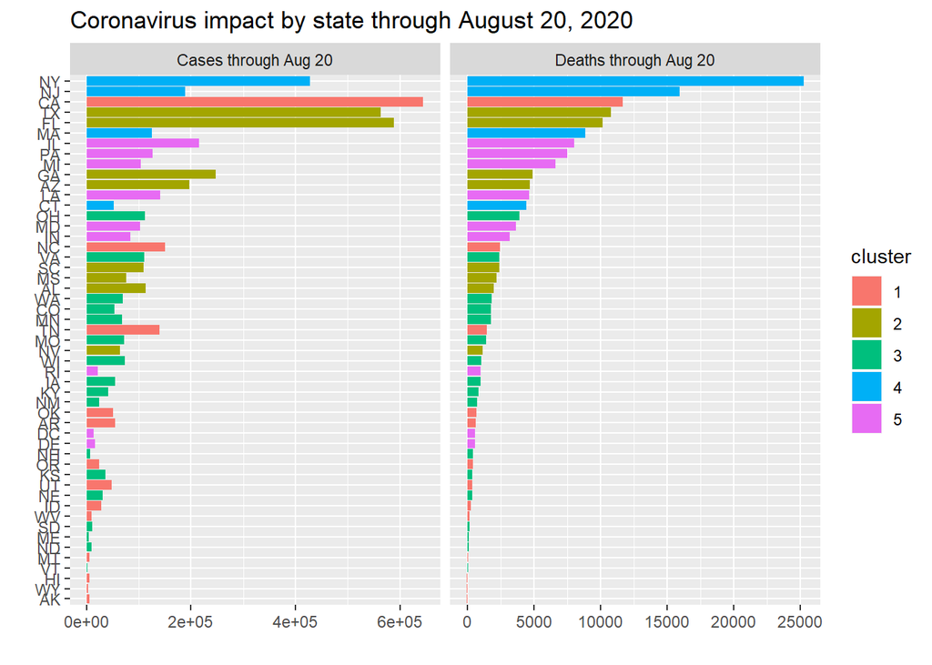

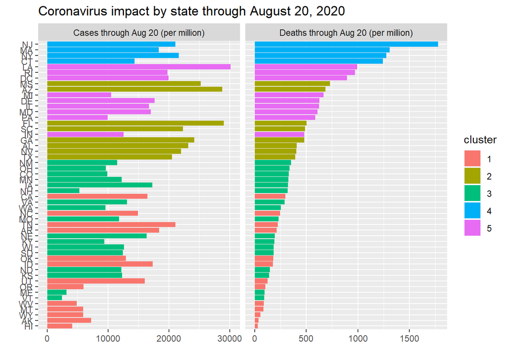

```
##
## Recency is defined as 2020-07-22 through current
```

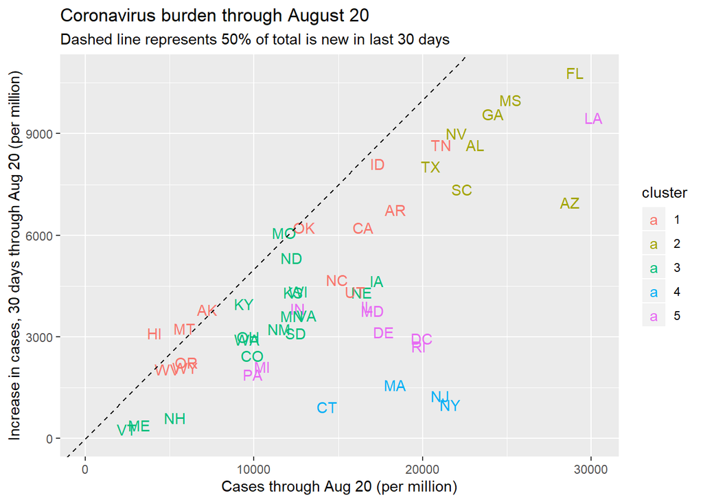

```
##
## Recency is defined as 2020-07-22 through current
```

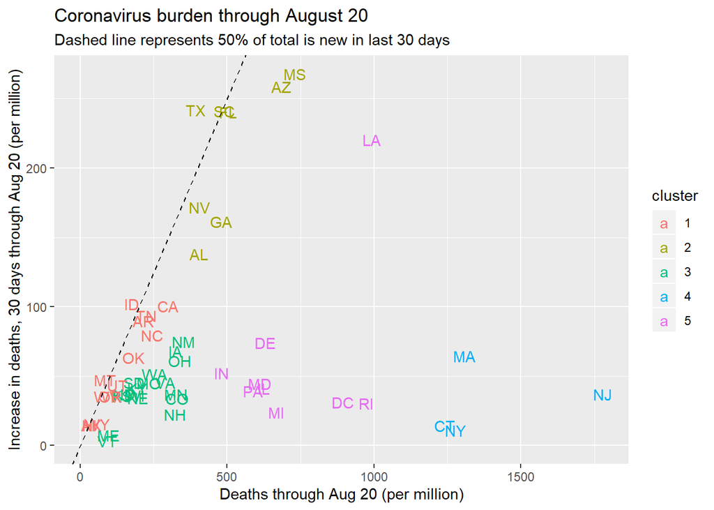

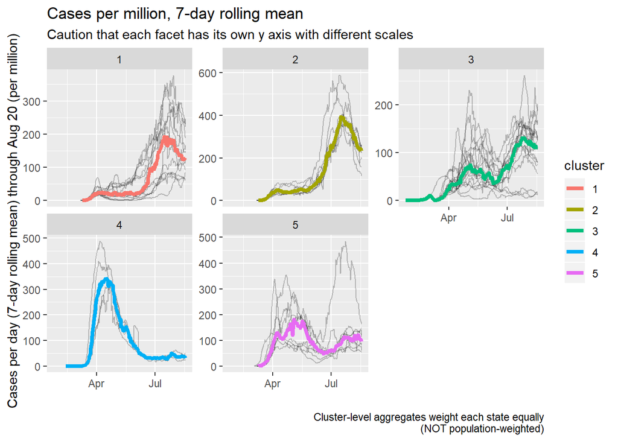

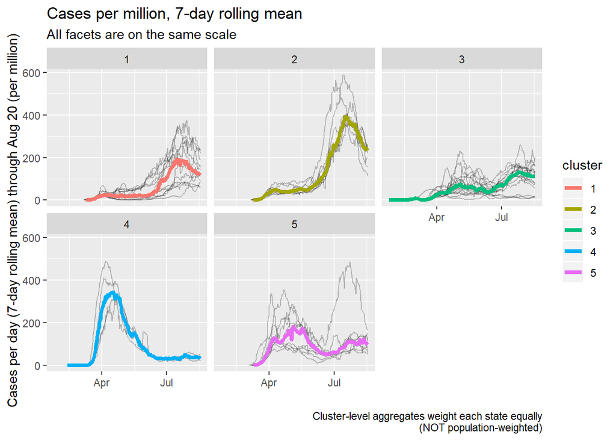

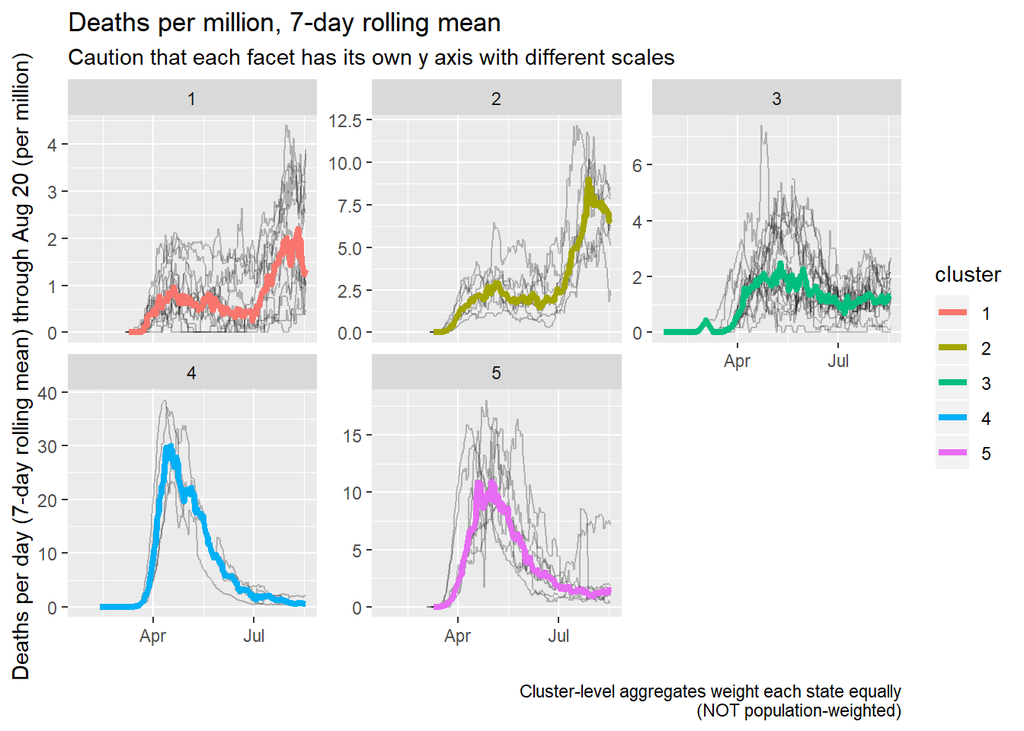

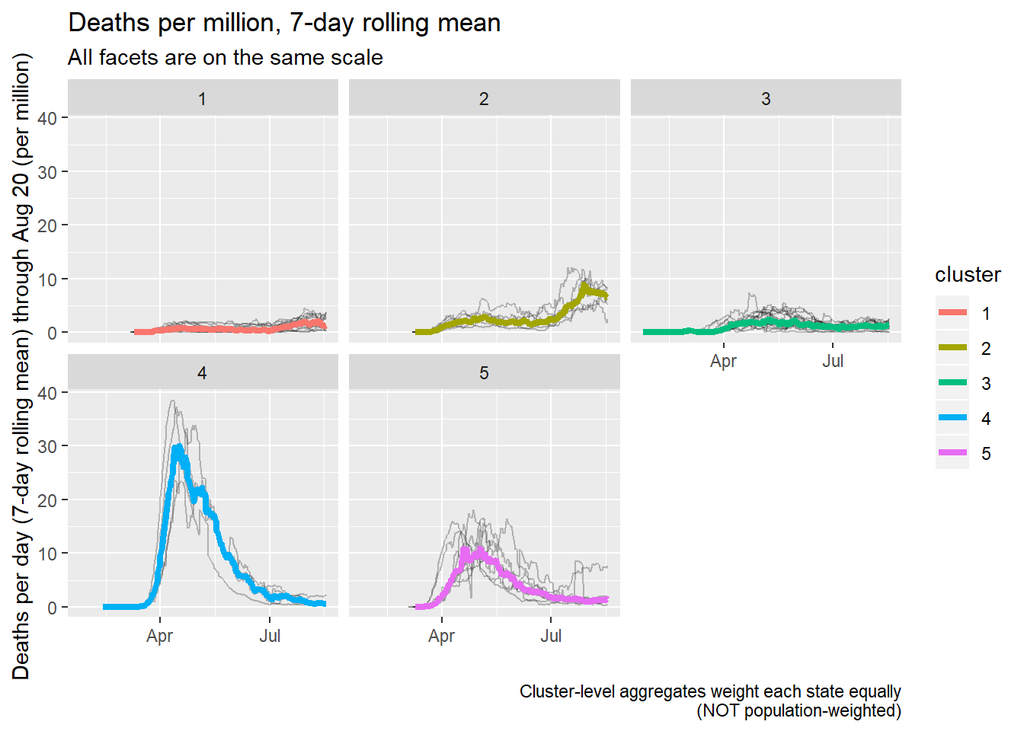

```r
# Helper function to assess 30-day change vs. total
helperRecentvsTotal <- function(df,
                                xVar,
                                yVar,
                                title,
                                recencyDays=30,
                                ablineSlope=0.5,
                                mapper=varMapper
                                ) {

    # FUNCTION ARGUMENTS:
    # df: the tibble containing data by state by day
    # xVar: the x-variable
    # yVar: the y-variable
    # title: the plot title
    # recencyDays: number of days to consider as recent
    # ablineSlope: dashed line will be drawn with this slope and intercept 0
    # mapper: mapping file to convert x/y variables to descriptive axes (named vector "variable"="label")

    # Get the most date cutoff
    dateCutoff <- df %>% pull(date) %>% max() - recencyDays + 1
    cat("\nRecency is defined as", format(dateCutoff, "%Y-%m-%d"), "through current\n")

    # Create the plot
    p1 <- df %>%
        mutate(newCases=ifelse(date >= dateCutoff, cases, 0),
               newDeaths=ifelse(date >= dateCutoff, deaths, 0),
               newcpm=ifelse(date >= dateCutoff, cpm, 0),
               newdpm=ifelse(date >= dateCutoff, dpm, 0)
               ) %>%
        group_by(state, cluster) %>%
        summarize_if(is.numeric, .funs=sum) %>%
        ungroup() %>%
        ggplot(aes_string(x=xVar, y=yVar)) +
        geom_text(aes(color=cluster, label=state)) +
        labs(x=mapper[xVar],
             y=mapper[yVar],
             title=title,
             subtitle=paste0("Dashed line represents ",
                             round(100*ablineSlope),
                             "% of total is new in last ",
                             recencyDays,
                             " days"
                             )
             ) +
        geom_abline(lty=2, slope=ablineSlope) +
        lims(x=c(0, NA), y=c(0, NA))
    print(p1)

}


# Function to plot cluster vs. individual elements on a key metric
helperTotalvsElements <- function(df,
                                  keyVar,
                                  title,
                                  aggFunc=median,
                                  mapper=varMapper,
                                  facetScales="free_y"
                                  ) {

    # FUNCTION ARGUMENTS:
    # df: the data frame containing n-day rolling averages
    # keyVar: the variable to be plotted
    # title: the plot title
    # aggFunc: how to aggregate the elements to the segment
    #          CAUTION that this is an aggregate of averages, rather than a population-weighted aggregate
    # mapper: the variable mapping file to get the appropriate label for keyVar
    # facetScales: the scaling for the facets - "free_y" to let them all float, "fixed" to have them the same

    # Create an appropriate subtitle
    subtitle <- if(facetScales=="free_y") {
        "Caution that each facet has its own y axis with different scales"
    } else if (facetScales=="fixed") {
        "All facets are on the same scale"
    } else {
        "Update subtitle code in function helperTotalvsElements"
    }

    # Create the plots for segment-level data
    p1 <- df %>%
        rbind(mutate(., state="cluster")) %>%
        group_by(state, cluster, date) %>%
        summarize_at(vars(all_of(keyVar)), .funs=aggFunc) %>%
        ungroup() %>%
        filter(!is.na(get(keyVar))) %>%
        ggplot(aes_string(x="date", y=keyVar)) +
        geom_line(data=~filter(., state != "cluster"), aes(group=state), alpha=0.25) +
        geom_line(data=~filter(., state == "cluster"), aes(group=state, color=cluster), lwd=1.5) +
        facet_wrap(~cluster, scales=facetScales) +
        labs(x="",
             y=mapper[keyVar],
             title=title,
             subtitle=subtitle,
             caption="Cluster-level aggregates weight each state equally\n(NOT population-weighted)"
             ) +
        ylim(c(0, NA))
    print(p1)

}



# Function to assess clusters
assessClusters <- function(clusters,
                           dfState=stateData,
                           dfBurden=cvFilteredPerCapita,
                           hierarchical=TRUE
                           ) {

    # FUNCTION ARGUMENTS:
    # clusters: the named vector containing the clusters
    # dfState: the file containing the states and populations
    # hierarchical: boolean, is this hierarchical data (FALSE means kmeans)
    #               currently only implemented for hieracrhical

    # Attach the clusters to the state population data
    if (hierarchical) {
        dfState <- as.data.frame(clusters) %>%
            set_names("cluster") %>%
            rownames_to_column("state") %>%
            inner_join(dfState, by="state") %>%
            mutate(cluster=factor(cluster))
    } else {
        stop("\nOnly hierarchical is currently implemented\n")
    }

    # Plot the segments on a state map
    p1 <- usmap::plot_usmap(regions="states", data=dfState, values="cluster")
    print(p1)

    # Plot the population totals by segment
    # Show population totals by cluster
    p2 <- dfState %>%
        group_by(cluster) %>%
        summarize(pop=sum(pop)/1000000) %>%
        ggplot(aes(x=cluster, y=pop)) +
        geom_col(aes(fill=cluster)) +
        geom_text(aes(y=pop/2, label=round(pop))) +
        labs(y="2015 population (millions)", x="Cluster", title="Population by cluster (millions)") +
        coord_flip()
    print(p2)

    # Plot the rolling 7-day mean dialy disease burden by cluster
    dfPlot <- dfState %>%
        inner_join(dfBurden, by="state") %>%
        tibble::as_tibble()

    # Plot the rolling 7-day mean dialy disease burden by cluster
    p3 <- dfPlot %>%
        select(date, cluster, cases=cpm7, deaths=dpm7) %>%
        pivot_longer(-c(date, cluster)) %>%
        filter(!is.na(value)) %>%
        group_by(date, cluster, name) %>%
        summarize(value=median(value)) %>%
        ggplot(aes(x=date, y=value)) +
        geom_line(aes(group=cluster, color=cluster)) +
        facet_wrap(~name, scales="free_y") +
        labs(x="",
             y="Rolling 7-day mean, per million",
             title="Rolling 7-day mean daily disease burden, per million",
             subtitle="Median per day for states assigned to cluster"
             )
    print(p3)

    # Plot the total cases and total deaths by cluster
    p4 <- dfPlot %>%
        group_by(cluster) %>%
        summarize(cases=sum(cases), deaths=sum(deaths)) %>%
        pivot_longer(-cluster) %>%
        ggplot(aes(x=cluster, y=value/1000)) +
        geom_col(aes(fill=cluster)) +
        geom_text(aes(y=value/2000, label=round(value/1000))) +
        coord_flip() +
        facet_wrap(~varMapper[name], scales="free_x") +
        labs(x="Cluster", y="Burden (000s)", title="Total cases and deaths by segment")
    print(p4)

    # Plot total cases and total deaths by state, colored by cluster
    helperBarDeathsCases(dfPlot,
                         numVars=c("cases", "deaths"),
                         title="Coronavirus impact by state through August 20, 2020",
                         xVar=c("state"),
                         fillVar=c("cluster")
                         )

    # Plot cases per million and deaths per million by state, colored by cluster
    helperBarDeathsCases(dfPlot,
                         numVars=c("cpm", "dpm"),
                         title="Coronavirus impact by state through August 20, 2020",
                         xVar=c("state"),
                         fillVar=c("cluster")
                         )

    # Plot last-30 vs total for cases per million by state, colored by cluster
    helperRecentvsTotal(dfPlot, xVar="cpm", yVar="newcpm", title="Coronavirus burden through August 20")

    # Plot last-30 vs total for deaths per million by state, colored by cluster
    helperRecentvsTotal(dfPlot, xVar="dpm", yVar="newdpm", title="Coronavirus burden through August 20")

    # Plot the cases per million on a free y-scale and a fixed y-scale
    helperTotalvsElements(dfPlot, keyVar="cpm7", title="Cases per million, 7-day rolling mean")
    helperTotalvsElements(dfPlot,
                          keyVar="cpm7",
                          title="Cases per million, 7-day rolling mean",
                          facetScales="fixed"
                          )

    # Plot the deaths per million on a free y-scale and a fixed y-scale
    helperTotalvsElements(dfPlot, keyVar="dpm7", title="Deaths per million, 7-day rolling mean")
    helperTotalvsElements(dfPlot,
                          keyVar="dpm7",
                          title="Deaths per million, 7-day rolling mean",
                          facetScales="fixed"
                          )


    # Return the plotting data frame
    dfPlot

}

# Check how 5 clusters look, with Vermont arbitrarily reassigned as the same cluster as New Hampshire
clustVec <- cutree(testCluster, k=6)
clustVec["VT"] <- clustVec["NH"]
plotData <- assessClusters(clustVec)
```